# Lecture Assignments - Using Models 1

Jordan Smith

2022-11-12

## Prep Work

```r
require("here")
catrate = read.csv(here("data", "catrate.csv"))
head(catrate)
```

```
##   pond success years  cat.rate
## 1    2       5     7 0.2857143
## 2    3       5     7 0.2857143
## 3    4       6     7 0.1428571
## 4    5       4     7 0.4285714
## 5    6       0     7 1.0000000
## 6    7       1     4 0.7500000
```

```r
summary(catrate)
```

```
##       pond       success          years          cat.rate
##  Min.   : 2   Min.   :0.000   Min.   :1.000   Min.   :0.1429
##  1st Qu.: 5   1st Qu.:1.000   1st Qu.:3.000   1st Qu.:0.2857
##  Median : 8   Median :2.000   Median :4.000   Median :0.4286
##  Mean   : 8   Mean   :2.538   Mean   :4.692   Mean   :0.5394
##  3rd Qu.:11   3rd Qu.:5.000   3rd Qu.:7.000   3rd Qu.:0.7500
##  Max.   :14   Max.   :6.000   Max.   :7.000   Max.   :1.0000
```

**Histogram of Catastrophe Rates**

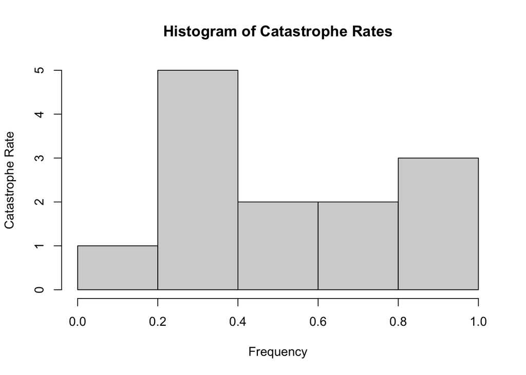

```r
hist(catrate$cat.rate,
     main = "Histogram of Catastrophe Rates",
     ylab = "Catastrophe Rate",
     xlab = "Frequency")
```

**Checking for Normality**

```r
#Shapiro Test
shapiro.test(catrate$cat.rate)
```

```
##
##  Shapiro-Wilk normality test
##
## data:  catrate$cat.rate
## W = 0.86202, p-value = 0.04097
```

```r
#Other Normality Tests
install.packages("nortest", repos = "http://cran.us.r-project.org")
library(nortest)

ad.test(catrate$cat.rate)
```

```
##
##  Anderson-Darling normality test
##
## data:  catrate$cat.rate
## A = 0.74221, p-value = 0.03945
```

```r
lillie.test(catrate$cat.rate)
```

```
##
##  Lilliefors (Kolmogorov-Smirnov) normality test
##
## data:  catrate$cat.rate
## D = 0.20906, p-value = 0.1246
```

**One-Sample Tests**

```r
#Parametric One-Sample Test: The t-test
t.test(x = catrate$cat.rate, mu = 0.2857143)
```

```
##
##  One Sample t-test
##
## data:  catrate$cat.rate
## t = 2.9595, df = 12, p-value = 0.01193
## alternative hypothesis: true mean is not equal to 0.2857143
## 95 percent confidence interval:
##  0.3526250 0.7261295
## sample estimates:
## mean of x
## 0.5393773
```

```r
#One-Sided Alternative Hypothesis
t.test(x = catrate$cat.rate, mu = 0.28571413, alternative = "greater")
```

```
##
##  One Sample t-test
##
## data:  catrate$cat.rate
## t = 2.9595, df = 12, p-value = 0.005966
## alternative hypothesis: true mean is greater than 0.2857141
## 95 percent confidence interval:
##  0.3866123       Inf
## sample estimates:
## mean of x
## 0.5393773
```

```r
#Non-Parametric One-Sample Test: The Wilcoxon Rank Sum Test
wilcox.test(catrate$cat.rate, mu = 2/7, exact = FALSE)
```

```
##
##  Wilcoxon signed rank test with continuity correction
##
## data:  catrate$cat.rate
## V = 85, p-value = 0.006275
## alternative hypothesis: true location is not equal to 0.2857143
```

```r
#One-Sided Alternative Hypothesis with The Wilcoxon Rank Sum Test
wilcox.test(catrate$cat.rate, mu = 2/7, alternative = "greater")
```

```
##
##  Wilcoxon signed rank test with continuity correction
##
## data:  catrate$cat.rate
## V = 85, p-value = 0.003137
## alternative hypothesis: true location is greater than 0.2857143
```

**Two-Sample Tests (Using Palmer Penguins)**

```r
require(palmerpenguins)
penguin_dat = droplevels(subset(penguins, species !="Gentoo"))
summary(penguin_dat)
```

```
##       species          island    bill_length_mm  bill_depth_mm
##  Adelie   :152   Biscoe   : 44   Min.   :32.10   Min.   :15.50
##  Chinstrap: 68   Dream    :124   1st Qu.:37.75   1st Qu.:17.50
##                  Torgersen: 52   Median :40.60   Median :18.40
##                                  Mean   :41.91   Mean   :18.37
##                                  3rd Qu.:45.95   3rd Qu.:19.10
##                                  Max.   :58.00   Max.   :21.50
##                                  NA's   :1       NA's   :1
##  flipper_length_mm  body_mass_g       sex           year
##  Min.   :172.0     Min.   :2700   female:107   Min.   :2007
##  1st Qu.:187.0     1st Qu.:3400   male  :107   1st Qu.:2007
##  Median :191.0     Median :3700   NA's  :  6   Median :2008
##  Mean   :191.8     Mean   :3711                Mean   :2008
##  3rd Qu.:196.0     3rd Qu.:3988                3rd Qu.:2009
##  Max.   :212.0     Max.   :4800                Max.   :2009
##  NA's   :1         NA's   :1
```

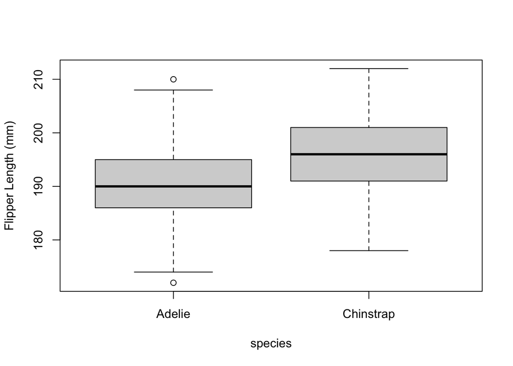

```r
#Visualizing a Conditional Boxplot
boxplot(
  flipper_length_mm ~ species,
  data = penguin_dat,
  ylab = "Flipper Length (mm)")
```

```r
#Testing for Normality
##Has to be done for each individual species
dat_adelie = subset(penguin_dat, species == "Adelie")
shapiro.test(dat_adelie$flipper_length_mm)
```

```
##
##  Shapiro-Wilk normality test
##
## data:  dat_adelie$flipper_length_mm
## W = 0.99339, p-value = 0.72
```

```r
wilcox.test(flipper_length_mm ~ species,
            data = penguin_dat)
```

```
##
##  Wilcoxon rank sum test with continuity correction
##
## data:  flipper_length_mm by species
## W = 2733.5, p-value = 3.028e-08
## alternative hypothesis: true location shift is not equal to 0
```

```r
dat_chinstrap = subset(penguin_dat, species == "Chinstrap")
shapiro.test(dat_chinstrap$flipper_length_mm)
```

```
##
##  Shapiro-Wilk normality test
##
## data:  dat_chinstrap$flipper_length_mm
## W = 0.98891, p-value = 0.8106
```

```r
#Parametric and NonParametric Tests
t.test(flipper_length_mm ~ species,
       data = penguin_dat)
```

```
##
##  Welch Two Sample t-test
##
## data:  flipper_length_mm by species
## t = -5.7804, df = 119.68, p-value = 6.049e-08
## alternative hypothesis: true difference in means between group Adelie and group Chinstrap is not equal to 0
## 95 percent confidence interval:
##  -7.880530 -3.859244
## sample estimates:
##    mean in group Adelie mean in group Chinstrap
##                189.9536                195.8235
```

## Question 1

**1. Create a histogram of the salamander reproduction catastrophic rates.**

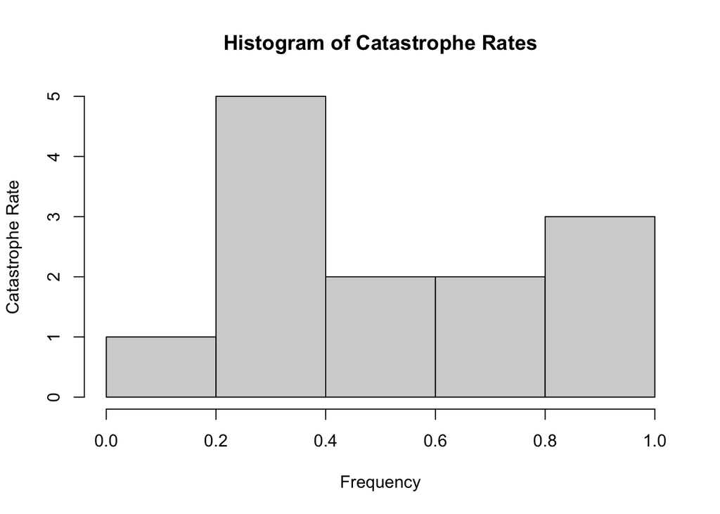

```r
hist(catrate$cat.rate,
     main = "Histogram of Catastrophe Rates",
     ylab = "Catastrophe Rate",
     xlab = "Frequency")
```

## Question 2 - 4

**2. Conduct a Shapiro-Wilk test of normality of the salamander catastrophic rates. Report the p-value and show the R-code you used to conduct the test.**

```r
shapiro.test(catrate$cat.rate)
```

```
##
##  Shapiro-Wilk normality test
##
## data:  catrate$cat.rate
## W = 0.86202, p-value = 0.04097
```

**3. What is the null hypothesis for the Shapiro test?** The null hypothesis states that the given data was sampled from a normally-distributed population.

**4. Based on the Shapiro test results, is there strong evidence that the sample came from a non-normally distributed population?** With a p-value of 0.04097, there is statistically significant evidence that the null-hypothesis can be rejected and the sample did not come from a normally distributed population.

## Question 5 - 7

*Conduct a one-sample t-test of the alternative hypothesis that the catastrophic rate is different from the pond-filling rate.*

**5. Show the code you used to conduct the t-test.**

```r
t.test(x = catrate$cat.rate, mu = 0.2857143)
```

```
##
##  One Sample t-test
##
## data:  catrate$cat.rate
## t = 2.9595, df = 12, p-value = 0.01193
## alternative hypothesis: true mean is not equal to 0.2857143
## 95 percent confidence interval:
##  0.3526250 0.7261295
## sample estimates:
## mean of x
## 0.5393773
```

**6. State the null hypothesis of the test, in plain nontechnical English.** The null hypothesis states that there is no difference in the catastrophic rate and the late-filling rate of marbled salamanders.

**7. Is this a one- or two-tailed test?** This is a two-tailed test since we are just checking to see if the catastrophic rate is different, not specifically greater or less than, the late-filling rate.

## Question 8 - 10

**8. What is the p-value from your t-test? Interpret the p-value as a false-positive rate using nontechnical English.** The p-value from this t-test is 0.01193, which from a false-positive perspective tells us that we would have incorrectly rejected the hypothesis that the two averages were different when in reality there was no statistical difference between them.

**9. What is the confidence interval for the difference between the null hypothesis and alternative hypothesis means? Did it include zero?** The confidence interval between the two is 0.3526250 - 0.7261295 and it does not include zero.

**10. Considering the results from your t-test, did you conclude that there was strong evidence to reject the null hypothesis?** Looking at the p-value of 0.01193, it is below p = 0.05 which tells us that we have grounds to reject the null hypothesis.

## Question 11 - 13

*Conduct a one-sample Wilcoxon rank sum test of the alternative hypothesis that the catastrophic rate is different from the pond late-filling rate. Interpret the results of your one-sample Wilcoxon rank sum test of the alternative hypothesis that the catastrophic rate is different from the pond-filling rate.*

**11. Show the code you used to conduct the test**

```r
wilcox.test(catrate$cat.rate, mu = 2/7, exact = FALSE)
```

```
##
##  Wilcoxon signed rank test with continuity correction
##
## data:  catrate$cat.rate
## V = 85, p-value = 0.006275
## alternative hypothesis: true location is not equal to 0.2857143
```

**12. Compare the p-value with the p-value you got from the t-test.**

t-test p-value = 0.01193 Wilcoxon Test p-value = 0.006275

**13. Considering the results from your rank sum test, did you conclude that there was strong evidence to reject the null hypothesis?** Since the p-value from the rank sum test was below p = 0.05, we have evidence to reject the null hypothesis that the two means are the same.

## Question 14 - 15

*Consider the one-sample t-test and Wilcoxon rank sum tests that you performed on the catastrophic rate data. Explain your reasoning*

**14. Compare the overall conclusions you could draw from the results of the two tests.** These two tests give us significant evidence that the means of the catastrophic rate and the late-filling rate are different, and that there may be additional factors in place to justify the catastropic rate of marbled salamanders.

**15. Considering the numerical and graphical data exploration, which test do you think was more appropriate for these data?** I think the t-test and wilcoxon rank sum tests were the most appropriate because they had outputs of specific values rather than an overal visual display.

## Question 16 - 17

**16. Show the R-code you used to conduct tests of normality for the flipper lengths of Chinstrap and Adelie penguins.**

```r
require(palmerpenguins)
penguin_dat = droplevels(subset(penguins, species !="Gentoo"))

dat_adelie = subset(penguin_dat, species == "Adelie")
shapiro.test(dat_adelie$flipper_length_mm)
```

```
##
##  Shapiro-Wilk normality test
##
## data:  dat_adelie$flipper_length_mm
## W = 0.99339, p-value = 0.72
```

```r
dat_chinstrap = subset(penguin_dat, species == "Chinstrap")
shapiro.test(dat_chinstrap$flipper_length_mm)
```

```
##
##  Shapiro-Wilk normality test
##
## data:  dat_chinstrap$flipper_length_mm
## W = 0.98891, p-value = 0.8106
```

```r
wilcox.test(flipper_length_mm ~ species,
            data = penguin_dat)
```

```
##
##  Wilcoxon rank sum test with continuity correction
##
## data:  flipper_length_mm by species
## W = 2733.5, p-value = 3.028e-08
## alternative hypothesis: true location shift is not equal to 0
```

**17. Interpret the test results. Do you conclude that the flipper lengths are normally-distributed for each species? Make sure your answers make reference to the test output.** Looking at the results of the Shapiro test for each of the species, Adelie penguins had a p-value = 0.72 and Chinstrap had a p-value = 0.81, both of these values indicating that the distribution of flipper lengths is normally distributed for both species.

## Question 18

*Create a single figure consisting of histograms of flipper lengths of Adelie and Chinstrap penguins. Your figure should have two histograms arranged in one row.*

**18. Save your figure to a file and include it to your report. Your figure needs to have appropriate dimensions such that the two histograms are not vertically stretched**

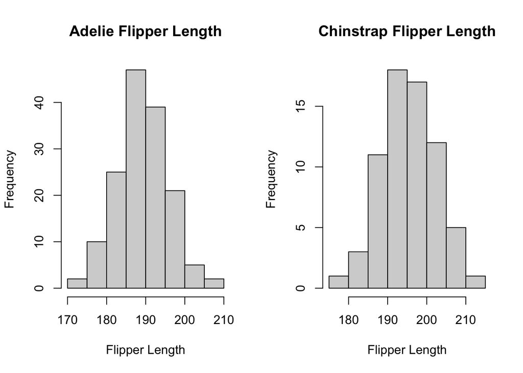

```r
par(mfrow = c(1,2))
hist(dat_adelie$flipper_length_mm,
     main = "Adelie Flipper Length",
     xlab = "Flipper Length",
     ylab = "Frequency")
hist(dat_chinstrap$flipper_length_mm,
     main = "Chinstrap Flipper Length",
     xlab = "Flipper Length",
     ylab = "Frequency")
```

## Question 19 - 20

*Conduct a two-sample t-test of the alternative hypothesis that the Adelie penguins have different flipper lengths than chinstrap penguins.*

**19. State the alternative hypothesis of the test, in plain nontechnical English** The alternative hypothesis for this test is that the flipper lengths of Adelie and Chinstrap penguins is different.

**20. Include the code you used to conduct the t-test.**

```r
t.test(flipper_length_mm ~ species, data = penguin_dat)
```

```
##
##  Welch Two Sample t-test
##
## data:  flipper_length_mm by species
## t = -5.7804, df = 119.68, p-value = 6.049e-08
## alternative hypothesis: true difference in means between group Adelie and group Chinstrap is not equal to 0
## 95 percent confidence interval:
##  -7.880530 -3.859244
## sample estimates:
##    mean in group Adelie mean in group Chinstrap
##                189.9536                195.8235
```